# Index

Welcome to my page! My name is Manya Vivek. I’m a Biology undergrad at UMass Amherst. This page is for my Evolutionary Genomics and Bininformatics lab.

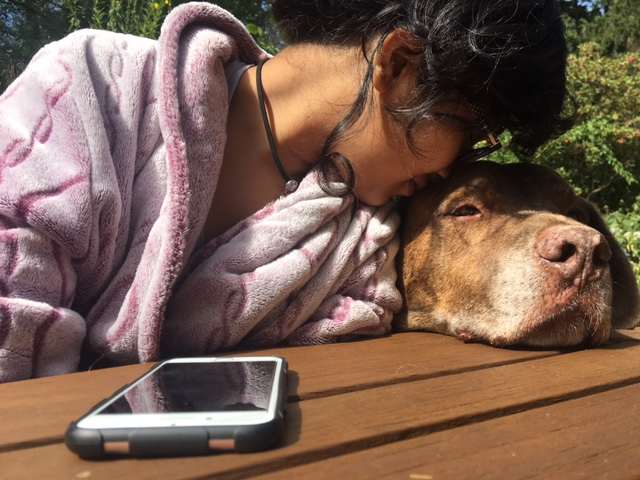

### LAB SUBMISSIONS:

- Lab1 - Introduction to R and Reproducible Research
- Lab2 - git, GitHub and R studio projects
- Lab3A - Starting with data
- Lab3B - Manipulating data
- Lab4 - Data wrangling and graphing COVID-19 reporting data (Part 1)
- Lab5 - Data wrangling and graphing COVID-19 reporting data (Part 2)
- Lab5 Extra - Interactive Graphs and Animations from the COVID-19 reporting data
- Lab6 - Data Maps and Interactive Graphs from the COVID-19 reporting data
- Lab 7 - RNA-Seq workflow: gene-level exploratory analysis and differential expression
- Lab 8 - Sequence Alignment, Phylogenetic Analysis and Tree Visualization
- Lab 9A : Programming in R - Regular Expressions
- Lab 9x: Programming in R - Control Structures and Functions
- Lab 10: Population genomics based on high throughput sequencing (HTS)
- Lab 11: Microbiome Analysis using dada2 and phyloseq
- Lab11x: Microbiome Analysis using phyloseq Introduction to Microbiome Analysis
- Lab12: Network Analysis using Cytoscape and RCy3